# Parte1_2_Chavez CHipana

#c 3B

```r
B1 <- diag(x = c(0,2,3,4),nrow = 4)
3*B1
```

```
##      [,1] [,2] [,3] [,4]
## [1,]    0    0    0    0
## [2,]    0    6    0    0
## [3,]    0    0    9    0
## [4,]    0    0    0   12
```

#d B*A

```r
B1%*%A1
```

```
##      [,1] [,2] [,3]
## [1,]    0    0    0
## [2,]    4    8   12
## [3,]    9   18   27
## [4,]   16   32   48
```

**P8 Piden crear una función para calcular P´6**

```r
p = matrix(c(1,2,3,-2,4,-2,1,0,1), nrow = 3, byrow = T)

f2 <- function(x,k){
  r <- diag(dim(x)[2])
  for(i in 1:k){
    r <- r%*%x
  }
  r
}
f2(p,6)
```

[output not shown]

```r
A2 <- rbind(c(3, -1, 1),
           c(9, -2, 1),
           c(3, 1, -2))
B2 <- c(-1, -9, -9)
solve(A2, B2)
```

```
## [1] -1  2  4
```

**P12 Considerando las matrices** A∗B−ABt

```r
B <- matrix(c(1:10, seq(2, 20, by = 2), seq(3, 30, by = 3), seq(4, 40, by = 4),
               seq(5, 50, by = 5)), nrow = 10)
A <- matrix(c(rep(c(0,1),7), rep(c(0,0,1),2),1,0,1,1,0), nrow = 5, byrow = T)

#Error en las dimensiones: (B)%*%(A)-(A)%*%t(B)
```

**p13 Considere** $β=(Xt∗X)−1∗Xt∗Y$ Piden determinar la matriz β

```r
x2 <- matrix(c(rep(1,5), 1, -1, 0:2), nrow = 5, byrow = F)
y2 <- matrix(c(0,0,1,1,3), nrow = 5, byrow = F)

solve(t(x2)%*%x2)%*%t(x2)%*%y2
```

```
##           [,1]
## [1,] 0.5384615
## [2,] 0.7692308
```

**P13 Piden cargar los vectores year y co2 con el siguiente código**

```r
data(co2)
means = aggregate(co2, FUN=mean)
year = as.vector(time(means))
co2 = as.vector(means)
```

- El vector `co2` contiene medidas de $CO_2$ en la atmósfera, en unidades de *ppm*, durante el periodo 1959-1997. El vector `year` contiene sus años correspondientes.
- Calcular un vector de diferencias de $CO_2$ entre años consecutivos, que sería:
  - $CO_2$ en 1960 menos $CO_2$ en 1959
  - $CO_2$ en 1961 menos $CO_2$ en 1960
  - y así sucesivamente…

```r
co2
```

```
##  [1] 315.8258 316.7475 317.4850 318.2975 318.8325 319.4625 319.8725 321.2100
##  [9] 322.0200 322.8900 324.4592 325.5175 326.1550 327.2933 329.5117 330.0792
## [17] 330.9858 331.9858 333.7300 335.3358 336.6808 338.5150 339.7608 340.9592
## [25] 342.6083 344.2467 345.7258 346.9750 348.7508 351.3133 352.7542 354.0367
## [33] 355.4783 356.2917 356.9958 358.8800 360.9142 362.6867 363.8175
```

```r
#Corremos los datos del vector a la derecha con lag()
lag(co2)
```

```
##  [1] 315.8258 316.7475 317.4850 318.2975 318.8325 319.4625 319.8725 321.2100
##  [9] 322.0200 322.8900 324.4592 325.5175 326.1550 327.2933 329.5117 330.0792
## [17] 330.9858 331.9858 333.7300 335.3358 336.6808 338.5150 339.7608 340.9592
## [25] 342.6083 344.2467 345.7258 346.9750 348.7508 351.3133 352.7542 354.0367
## [33] 355.4783 356.2917 356.9958 358.8800 360.9142 362.6867 363.8175
## attr(,"tsp")
## [1]  0 38  1
```

```r
dif <- co2 - dplyr::lag(co2)
dif
```

```
##  [1]        NA 0.9216667 0.7375000 0.8125000 0.5350000 0.6300000 0.4100000
##  [8] 1.3375000 0.8100000 0.8700000 1.5691667 1.0583333 0.6375000 1.1383333
## [15] 2.2183333 0.5675000 0.9066667 1.0000000 1.7441667 1.6058333 1.3450000
## [22] 1.8341667 1.2458333 1.1983333 1.6491667 1.6383333 1.4791667 1.2491667
## [29] 1.7758333 2.5625000 1.4408333 1.2825000 1.4416667 0.8133333 0.7041667
## [36] 1.8841667 2.0341667 1.7725000 1.1308333
```

- Crear un **plot** con lineas y puntos mostrando las diferencias consecutivas de $CO_2$ en función del tiempo (1960, 1961, etc…), en **negrita**

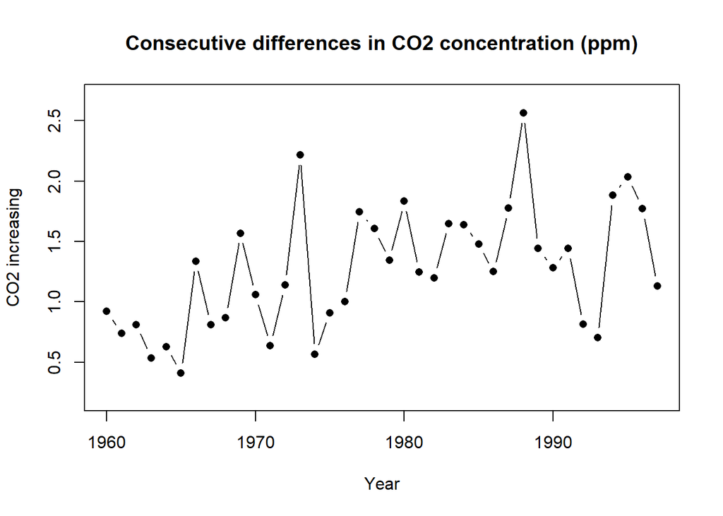

```r
plot(x = year, y = dif,
     type = "b",
     pch = 16,
     xlab = "Year",
     ylab = "CO2 increasing",
     main = "Consecutive differences in CO2 concentration (ppm)",
     xlim = c(1960, 1997),
     ylim = c(0.2, 2.7)
     )
```

- La diferencia de concentración de $CO_2$ entre 2020 y 2019 fue igual a 2.64. Agregar un punto rojo representando esa diferencia al plot ya creado (usar una forma diferente, como `pch=4`)

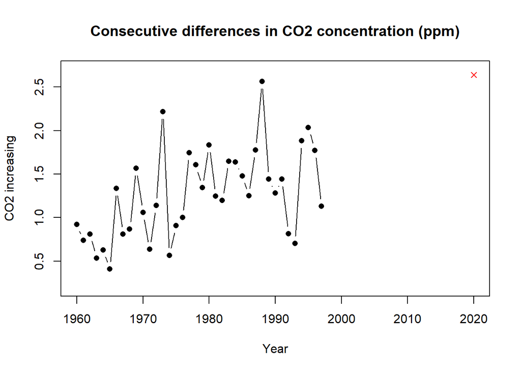

```r
dif_2020_2019 <- 2.64
year_2020 <- 2020

plot(x = year, y = dif,
     type = "b",
     pch = 16,
     xlab = "Year",
     ylab = "CO2 increasing",
     main = "Consecutive differences in CO2 concentration (ppm)",
     xlim = c(1960, 2020),
     ylim = c(0.2, 2.7))
points(x = year_2020, y = dif_2020_2019, pch = 4, col = "red")
```

**P14 Piden:Leer el archivo rainfall.csv como un data.frame Calcula e imprime un vector con los nombres de las estaciones donde al menos uno de los meses tiene una precipitación superior a 180mm**

```r
library(tidyverse)
rain <- as_tibble(read.csv("C:/Users/CHAVEZ/Downloads/ProgramacionR-master/data/rainfall.csv"))
rain
```

```
## # A tibble: 169 x 14
##       num altitude   sep   oct   nov   dec   jan   feb   mar   apr   may name
##     <int>    <int> <dbl> <int> <int> <int> <int> <int> <int> <int> <dbl> <chr>
##  1 110050       30   1.2    33    90   117   135   102    61    20   6.7 Kfar R~
##  2 110351       35   2.3    34    86   121   144   106    62    23   4.5 Saar
##  3 110502       20   2.7    29    89   131   158   109    62    24   3.8 Evron
##  4 111001       10   2.9    32    91   137   152   113    61    21   4.8 Kfar M~
##  5 111650       25   1      27    78   128   136   108    59    21   4.7 Kfar H~
##  6 120202        5   1.5    27    80   127   136    95    49    19   2.7 Haifa ~
##  7 120630      450   1.9    36    93   161   166   128    71    21   4.9 Haifa ~
##  8 120750       30   1.6    31    91   163   170   146    76    22   4.9 Yagur
##  9 120870      210   1.1    32    93   147   147   109    61    16   4.3 Nir Et~
## 10 121051       20   1.8    32    85   147   142   102    56    13   4.5 En Car~
## # ... with 159 more rows, and 2 more variables: x_utm <dbl>, y_utm <dbl>
```

```r
df_rain <- data.frame(rain)
names_est <- dplyr::select(df_rain, sep:apr, name) %>%
dplyr::filter(sep > 180 | oct > 180 | nov > 180 | dec > 180 |
                jan > 180 | feb > 180 |mar >180) %>%
dplyr::select(name)
names_est <- as.vector(names_est$name)
names_est
```

```
## [1] "Golan Farm" "Eilon"      "Fasutta"    "Yehiam"     "Kfar Mahol"
## [6] "Meron"      "Horashim"
```